# STK4300 - Assignment 2

Kyunhee Park

2024-10-30

# Problem 1. Regression

Data load and preprocessing

```r
data_raw_q1 <- read.csv2("data/qsar_aquatic_toxicity.csv", header = FALSE)
colnames(data_raw_q1) <- c("TPSA", "SAacc", "H050", "MLOGP", "RDCHI", "GATS1p", "nN", "C040", "LC50")

data_raw_q1 <- data_raw_q1 %>%
  dplyr::mutate_all(as.numeric)
```

## 1-(a) Plain linear regression.

Train-test set split

```r
set.seed(123)

sample <- sample(c(TRUE, FALSE), nrow(data_raw_q1), replace=TRUE, prob=c(2/3, 1/3))
train_data  <- data_raw_q1[sample, ]
test_data   <- data_raw_q1[!sample, ]
```

### 1-(a)-(i) Regression - linear effect.

1. model each of them directly as a linear effect

```r
linear_reg_mdl_linear <- lm(LC50 ~ TPSA + SAacc + H050 + MLOGP + RDCHI + GATS1p + nN + C040,
                            data = train_data)

train_pred_linear <- predict(linear_reg_mdl_linear, train_data)
test_pred_linear <- predict(linear_reg_mdl_linear, test_data)

# Performance metrics: MSE
train_error_linear <- mean((train_pred_linear - train_data$LC50)^2)
test_error_linear <- mean((test_pred_linear - test_data$LC50)^2)

summary(linear_reg_mdl_linear)
```

```
##
## Call:
## lm(formula = LC50 ~ TPSA + SAacc + H050 + MLOGP + RDCHI + GATS1p +
##     nN + C040, data = train_data)
##
## Residuals:
##     Min      1Q  Median      3Q     Max
## -2.8330 -0.8171 -0.1772  0.6877  4.8906
##
## Coefficients:
##              Estimate Std. Error t value Pr(>|t|)
## (Intercept)  2.640765   0.311302   8.483 5.91e-16 ***
## TPSA         0.027187   0.003326   8.175 5.21e-15 ***
## SAacc       -0.016012   0.002643  -6.059 3.48e-09 ***
## H050        -0.002396   0.076152  -0.031 0.974919
## MLOGP        0.405108   0.081389   4.977 1.00e-06 ***
## RDCHI        0.640054   0.176240   3.632 0.000323 ***
## GATS1p      -0.586096   0.194771  -3.009 0.002806 **
## nN          -0.196389   0.059247  -3.315 0.001011 **
## C040        -0.040081   0.090632  -0.442 0.658586
## ---
## Signif. codes:  0 '***' 0.001 '**' 0.01 '*' 0.05 '.' 0.1 ' ' 1
##
## Residual standard error: 1.217 on 357 degrees of freedom
## Multiple R-squared:  0.502,  Adjusted R-squared:  0.4909
## F-statistic: 44.99 on 8 and 357 DF,  p-value: < 2.2e-16
```

### 1-(a)-(ii) Regression - Dummy encoding.

2. transform each of them using a 0/1 dummy encoding where 0 represents absence of the specific atom and 1 represents presence of the specific atoms.

**Data encoding**

```r
train_data_encode <- train_data %>%
  dplyr::mutate(H050_encode = ifelse(H050 > 0, 1, 0),
                nN_encode = ifelse(nN > 0, 1, 0),
                C040_encode = ifelse(C040 > 0, 1, 0)) %>%
  dplyr::select(-H050, -nN, -C040)

test_data_encode <- test_data %>%
  dplyr::mutate(H050_encode = ifelse(H050 > 0, 1, 0),
                nN_encode = ifelse(nN > 0, 1, 0),
                C040_encode = ifelse(C040 > 0, 1, 0)) %>%
  dplyr::select(-H050, -nN, -C040)
```

**Model training**

```r
linear_reg_mdl_encode <- lm(LC50 ~ TPSA + SAacc + H050_encode + MLOGP +
                              RDCHI + GATS1p + nN_encode + C040_encode,
                            data = train_data_encode)

train_pred_encode <- predict(linear_reg_mdl_encode, train_data_encode)
test_pred_encode <- predict(linear_reg_mdl_encode, test_data_encode)

# Performance metrics: MSE
train_error_encode <- mean((train_pred_encode - train_data_encode$LC50)^2)
test_error_encode <- mean((test_pred_encode - test_data_encode$LC50)^2)

summary(linear_reg_mdl_encode)
```

```
##
## Call:
## lm(formula = LC50 ~ TPSA + SAacc + H050_encode + MLOGP + RDCHI +
##     GATS1p + nN_encode + C040_encode, data = train_data_encode)
##
## Residuals:
##     Min      1Q  Median      3Q     Max
## -3.0976 -0.8283 -0.1330  0.6584  5.0538
##
## Coefficients:
##              Estimate Std. Error t value Pr(>|t|)
## (Intercept)  2.703381   0.314659   8.591 2.71e-16 ***
## TPSA         0.023375   0.003350   6.978 1.46e-11 ***
## SAacc       -0.014731   0.002401  -6.136 2.25e-09 ***
## H050_encode -0.090059   0.160923  -0.560  0.57608
## MLOGP        0.439031   0.082294   5.335 1.70e-07 ***
## RDCHI        0.543246   0.178733   3.039  0.00255 **
## GATS1p      -0.538491   0.189791  -2.837  0.00481 **
## nN_encode    0.017707   0.154795   0.114  0.90899
## C040_encode -0.118594   0.168223  -0.705  0.48128
## ---
## Signif. codes:  0 '***' 0.001 '**' 0.01 '*' 0.05 '.' 0.1 ' ' 1
##
## Residual standard error: 1.236 on 357 degrees of freedom
## Multiple R-squared:  0.4865, Adjusted R-squared:  0.475
## F-statistic: 42.27 on 8 and 357 DF,  p-value: < 2.2e-16
```

- Linear effect has lower error on both Train and Test set.
- Encoding H050, nN, C040 induces information losses.

## 1-(b) Bootstrap - linear regression.

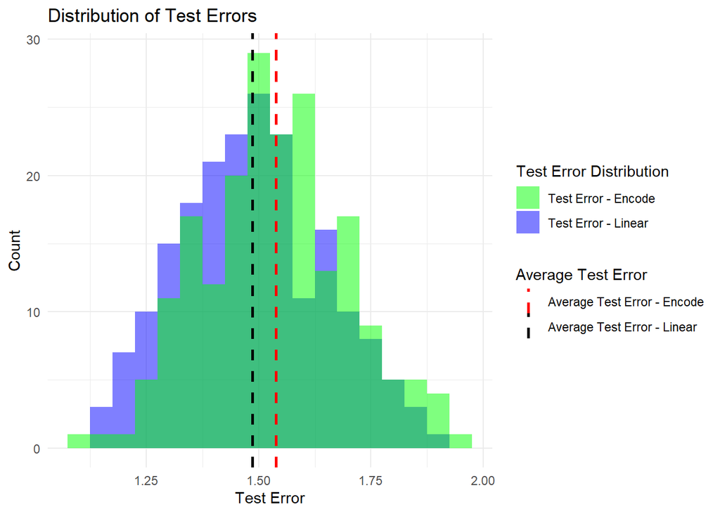

```r
model_training <- function(input_df) {

  sample <- sample(c(TRUE, FALSE), nrow(input_df), replace=TRUE, prob=c(2/3, 1/3))
  train_data  <- input_df[sample, ]
  test_data   <- input_df[!sample, ]

  train_data_encode <- train_data %>%
  dplyr::mutate(H050_encode = ifelse(H050 > 0, 1, 0),
                nN_encode = ifelse(nN > 0, 1, 0),
                C040_encode = ifelse(C040 > 0, 1, 0)) %>%
  dplyr::select(-H050, -nN, -C040)

  test_data_encode <- test_data %>%
    dplyr::mutate(H050_encode = ifelse(H050 > 0, 1, 0),
                  nN_encode = ifelse(nN > 0, 1, 0),
                  C040_encode = ifelse(C040 > 0, 1, 0)) %>%
    dplyr::select(-H050, -nN, -C040)

  mdl_linear <- lm(LC50 ~ TPSA + SAacc + H050 + MLOGP + RDCHI + GATS1p + nN + C040,
                   data = train_data)

  train_pred_linear <- predict(mdl_linear, train_data)
  test_pred_linear <- predict(mdl_linear, test_data)

  train_error_linear <- mean((train_pred_linear - train_data$LC50)^2)
  test_error_linear <- mean((test_pred_linear - test_data$LC50)^2)


  mdl_encode <- lm(LC50 ~ TPSA + SAacc + H050_encode + MLOGP + RDCHI +
                     GATS1p + nN_encode + C040_encode,
                   data = train_data_encode)

  train_pred_encode <- predict(mdl_encode, train_data_encode)
  test_pred_encode <- predict(mdl_encode, test_data_encode)

  train_error_encode <- mean((train_pred_encode - train_data_encode$LC50)^2)
  test_error_encode <- mean((test_pred_encode - test_data_encode$LC50)^2)

  return(
    list(
      train_error_linear = train_error_linear,
      test_error_linear = test_error_linear,
      train_error_encode = train_error_encode,
      test_error_encode = test_error_encode)
    )
}

bootstrap_train_test_error_df <- purrr::map_dfr(1:200, ~ model_training(data_raw_q1))

bootstrap_avg_test_error_linear <- mean(bootstrap_train_test_error_df$test_error_linear)
bootstrap_avg_test_error_encode <- mean(bootstrap_train_test_error_df$test_error_encode)

ggplot(bootstrap_train_test_error_df) +
  geom_histogram(aes(x = test_error_linear, fill = "Test Error - Linear"),
                 binwidth = 0.05, alpha = 0.5) +
  geom_histogram(aes(x = test_error_encode, fill = "Test Error - Encode"),
                 binwidth = 0.05, alpha = 0.5) +
  geom_vline(aes(xintercept = bootstrap_avg_test_error_linear,
                 color = "Average Test Error - Linear"),
             linetype = "dashed", size = 1) +
  geom_vline(aes(xintercept = bootstrap_avg_test_error_encode,
                 color = "Average Test Error - Encode"),
             linetype = "dashed", size = 1) +
  scale_fill_manual(
    name = "Test Error Distribution",
    values = c("Test Error - Linear" = "blue", "Test Error - Encode" = "green")
  ) +
  scale_color_manual(
    name = "Average Test Error",
    values = c("Average Test Error - Linear" = "black", "Average Test Error - Encode" = "red")
  ) +
  labs(
    title = "Distribution of Test Errors",
    x = "Test Error",
    y = "Count"
  ) +
  theme_minimal()
```

- We reduce the influence of any particular train-test split that could have been unusually favorable or unfavorable for either model.
- This allows us to observe the average performance and variability of each model under different data conditions, providing a more stable insight into each model’s effectiveness.
- Dummy encoding in Option (ii) can lead to worse performance because it reduces the granularity of information for count variables (like H050, nN, C040).
- When we replace continuous or count data with binary indicators, we lose information about the magnitude of these variables. For instance, whether a molecule has one nitrogen atom or five becomes indistinguishable once we binarize it. This simplification can lead to a loss in predictive power, as the actual count values may carry nuanced information relevant to toxicity predictions. Thus, models using dummy encoding often struggle to capture relationships that might be effectively captured by the original count values, leading to higher test errors.

## 1-(c) Variable selection.

**Variable selection** - Forward selection and Backward elimination - AIC, BIC

```r
full_model <- lm(LC50 ~ TPSA + SAacc + H050 + MLOGP + RDCHI + GATS1p + nN + C040,
                 data = train_data)

null_model <- lm(LC50 ~ 1,
                 data = train_data)

# Backward, AIC
backward_aic <- step(full_model, direction = "backward", k = 2)
```

```
## Start:  AIC=152.55
## LC50 ~ TPSA + SAacc + H050 + MLOGP + RDCHI + GATS1p + nN + C040
##
##          Df Sum of Sq    RSS    AIC
## - H050    1     0.001 528.61 150.55
## - C040    1     0.290 528.90 150.75
## <none>                528.61 152.55
## - GATS1p  1    13.408 542.02 159.72
## - nN      1    16.270 544.88 161.64
## - RDCHI   1    19.530 548.14 163.83
## - MLOGP   1    36.684 565.30 175.11
## - SAacc   1    54.354 582.96 186.37
## - TPSA    1    98.961 627.57 213.36
##
## Step:  AIC=150.55
## LC50 ~ TPSA + SAacc + MLOGP + RDCHI + GATS1p + nN + C040
##
##          Df Sum of Sq    RSS    AIC
## - C040    1     0.308 528.92 148.76
## <none>                528.61 150.55
## - GATS1p  1    14.930 543.54 158.74
## - nN      1    17.106 545.72 160.21
## - RDCHI   1    19.540 548.15 161.84
## - MLOGP   1    39.545 568.16 174.95
## - SAacc   1    79.186 607.80 199.64
## - TPSA    1   101.781 630.39 213.00
##
## Step:  AIC=148.76
## LC50 ~ TPSA + SAacc + MLOGP + RDCHI + GATS1p + nN
##
##          Df Sum of Sq    RSS    AIC
## <none>                528.92 148.76
## - GATS1p  1    15.101 544.02 157.07
## - nN      1    17.362 546.28 158.58
## - RDCHI   1    19.260 548.18 159.85
## - MLOGP   1    39.979 568.90 173.43
## - SAacc   1    81.945 610.87 199.48
## - TPSA    1   101.889 630.81 211.24
```

```r
# Backward, BIC
backward_bic <- step(full_model, direction = "backward", k = log(nrow(train_data)))
```

```
## Start:  AIC=187.67
## LC50 ~ TPSA + SAacc + H050 + MLOGP + RDCHI + GATS1p + nN + C040
##
##          Df Sum of Sq    RSS    AIC
## - H050    1     0.001 528.61 181.77
## - C040    1     0.290 528.90 181.97
## <none>                528.61 187.67
## - GATS1p  1    13.408 542.02 190.94
## - nN      1    16.270 544.88 192.86
## - RDCHI   1    19.530 548.14 195.05
## - MLOGP   1    36.684 565.30 206.33
## - SAacc   1    54.354 582.96 217.59
## - TPSA    1    98.961 627.57 244.58
##
## Step:  AIC=181.77
## LC50 ~ TPSA + SAacc + MLOGP + RDCHI + GATS1p + nN + C040
##
##          Df Sum of Sq    RSS    AIC
## - C040    1     0.308 528.92 176.08
## <none>                528.61 181.77
## - GATS1p  1    14.930 543.54 186.06
## - nN      1    17.106 545.72 187.52
## - RDCHI   1    19.540 548.15 189.15
## - MLOGP   1    39.545 568.16 202.27
## - SAacc   1    79.186 607.80 226.96
## - TPSA    1   101.781 630.39 240.32
##
## Step:  AIC=176.08
## LC50 ~ TPSA + SAacc + MLOGP + RDCHI + GATS1p + nN
##
##          Df Sum of Sq    RSS    AIC
## <none>                528.92 176.08
## - GATS1p  1    15.101 544.02 180.48
## - nN      1    17.362 546.28 182.00
## - RDCHI   1    19.260 548.18 183.27
## - MLOGP   1    39.979 568.90 196.85
## - SAacc   1    81.945 610.87 222.90
## - TPSA    1   101.889 630.81 234.66
```

```r
# Forward, AIC
forward_aic <- step(null_model, scope = formula(full_model), direction = "forward", k = 2)
```

```
## Start:  AIC=391.72
## LC50 ~ 1
##
##          Df Sum of Sq     RSS    AIC
## + MLOGP   1    336.74  724.77 254.06
## + RDCHI   1    174.85  886.66 327.85
## + GATS1p  1    111.33  950.18 353.17
## + H050    1     47.25 1014.26 377.06
## + SAacc   1     13.50 1048.01 389.04
## + nN      1      5.93 1055.58 391.67
## <none>                1061.51 391.72
## + TPSA    1      0.33 1061.18 393.61
## + C040    1      0.27 1061.24 393.63
##
## Step:  AIC=254.06
## LC50 ~ MLOGP
##
##          Df Sum of Sq    RSS    AIC
## + TPSA    1    91.829 632.94 206.47
## + RDCHI   1    46.762 678.01 231.65
## + SAacc   1    13.351 711.42 249.25
## + GATS1p  1    11.269 713.50 250.32
## + nN      1     9.460 715.31 251.25
## + C040    1     5.177 719.59 253.44
## + H050    1     4.831 719.94 253.61
## <none>                724.77 254.06
##
## Step:  AIC=206.47
## LC50 ~ MLOGP + TPSA
##
##          Df Sum of Sq    RSS    AIC
## + SAacc   1    66.957 565.98 167.55
## + H050    1    14.343 618.60 200.08
## + GATS1p  1    11.919 621.02 201.51
## + nN      1     9.017 623.92 203.22
## + C040    1     5.130 627.81 205.50
## <none>                632.94 206.47
## + RDCHI   1     2.162 630.78 207.22
##
## Step:  AIC=167.55
```

[output cut: 21 more lines]

```
## LC50 ~ MLOGP + TPSA + SAacc + nN + RDCHI
##
##          Df Sum of Sq    RSS    AIC
## + GATS1p  1   15.1011 528.92 148.76
## <none>                544.02 157.07
## + H050    1    1.9309 542.09 157.76
## + C040    1    0.4797 543.54 158.74
##
## Step:  AIC=148.76
## LC50 ~ MLOGP + TPSA + SAacc + nN + RDCHI + GATS1p
##
##        Df Sum of Sq    RSS    AIC
## <none>              528.92 148.76
## + C040  1  0.308269 528.61 150.55
## + H050  1  0.020149 528.90 150.75
```

```r
# Forward, BIC
forward_bic <- step(null_model, scope = formula(full_model),
                    direction = "forward", k = log(nrow(train_data)))
```

```
## Start:  AIC=395.63
## LC50 ~ 1
##
##          Df Sum of Sq     RSS    AIC
## + MLOGP   1    336.74  724.77 261.86
## + RDCHI   1    174.85  886.66 335.65
## + GATS1p  1    111.33  950.18 360.98
## + H050    1     47.25 1014.26 384.86
## <none>                1061.51 395.63
## + SAacc   1     13.50 1048.01 396.84
## + nN      1      5.93 1055.58 399.48
## + TPSA    1      0.33 1061.18 401.42
## + C040    1      0.27 1061.24 401.43
##
## Step:  AIC=261.86
## LC50 ~ MLOGP
##
##          Df Sum of Sq    RSS    AIC
## + TPSA    1    91.829 632.94 218.18
## + RDCHI   1    46.762 678.01 243.36
## + SAacc   1    13.351 711.42 260.96
## <none>                724.77 261.86
## + GATS1p  1    11.269 713.50 262.03
## + nN      1     9.460 715.31 262.96
## + C040    1     5.177 719.59 265.14
## + H050    1     4.831 719.94 265.32
##
## Step:  AIC=218.18
## LC50 ~ MLOGP + TPSA
##
##          Df Sum of Sq    RSS    AIC
## + SAacc   1    66.957 565.98 183.16
## + H050    1    14.343 618.60 215.69
## + GATS1p  1    11.919 621.02 217.13
## <none>                632.94 218.18
## + nN      1     9.017 623.92 218.83
## + C040    1     5.130 627.81 221.10
## + RDCHI   1     2.162 630.78 222.83
##
## Step:  AIC=183.16
```

[output cut: 21 more lines]

```
## LC50 ~ MLOGP + TPSA + SAacc + nN + RDCHI
##
##          Df Sum of Sq    RSS    AIC
## + GATS1p  1   15.1011 528.92 176.08
## <none>                544.02 180.48
## + H050    1    1.9309 542.09 185.08
## + C040    1    0.4797 543.54 186.06
##
## Step:  AIC=176.08
## LC50 ~ MLOGP + TPSA + SAacc + nN + RDCHI + GATS1p
##
##        Df Sum of Sq    RSS    AIC
## <none>              528.92 176.08
## + C040  1  0.308269 528.61 181.77
## + H050  1  0.020149 528.90 181.97
```

```r
selected_backward_aic <- names(coef(backward_aic))[-1]
selected_backward_bic <- names(coef(backward_bic))[-1]
selected_forward_aic <- names(coef(forward_aic))[-1]
selected_forward_bic <- names(coef(forward_bic))[-1]
```

```r
cat("Backward Selection (AIC):", selected_backward_aic, "\n")
```

```
## Backward Selection (AIC): TPSA SAacc MLOGP RDCHI GATS1p nN
```

```r
cat("Backward Selection (BIC):", selected_backward_bic, "\n")
```

```
## Backward Selection (BIC): TPSA SAacc MLOGP RDCHI GATS1p nN
```

```r
cat("Forward Selection (AIC):", selected_forward_aic, "\n")
```

```
## Forward Selection (AIC): MLOGP TPSA SAacc nN RDCHI GATS1p
```

```r
cat("Forward Selection (BIC):", selected_forward_bic, "\n")
```

```
## Forward Selection (BIC): MLOGP TPSA SAacc nN RDCHI GATS1p
```

- The variable selection shows the same result for Backward- and Forward selection on both AIC and BIC criteria.

```r
variable_selected_formula <- as.formula(paste("LC50 ~",
                                          paste(selected_forward_aic, collapse = " + ")))

variable_selected_mdl <- lm(variable_selected_formula,
                            data = test_data)

variable_selected_mdl_test_error <- mean((variable_selected_mdl$fitted.values - test_data$LC50)^2)

cat("Test error (Variable selection) :", variable_selected_mdl_test_error, "\n")
```

```
## Test error (Variable selection) : 1.328515
```

## 1-(d) Apply ridge regression and use both a bootstrap procedure.

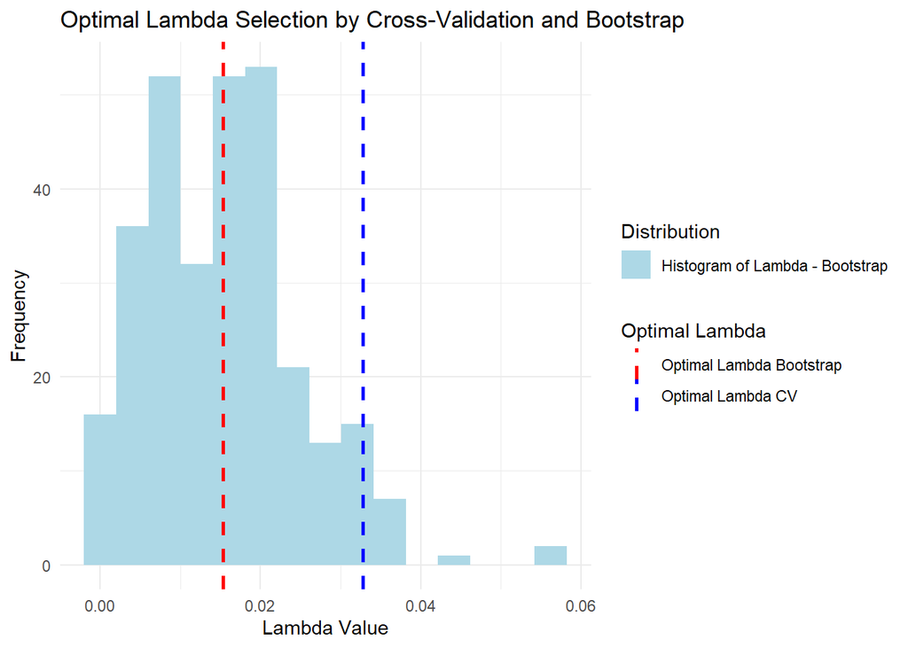

```r
X <- as.matrix(train_data %>% dplyr::select(-LC50))
y <- train_data$LC50

# Lambda grid
lambda_grid <- 10^seq(3, -3, length = 100)

# CV - optimal lamnda
set.seed(123)
cv_ridge <- cv.glmnet(X, y, alpha = 0, lambda = lambda_grid, nfolds = 5)
optimal_lambda_cv <- cv_ridge$lambda.min

# Bootstrap to find optimal lambda
bootstrap_ridge <- function(data, indices) {
  # Bootstrap resampling
  X_boot <- X[indices, ]
  y_boot <- y[indices]

  # Use cross-validation on bootstrap sample to find the best lambda
  cv_fit <- cv.glmnet(X_boot, y_boot, alpha = 0, lambda = lambda_grid, nfolds = 5)
  return(cv_fit$lambda.min)
}

# Bootstraping
bootstrap_results <- boot(data = train_data, statistic = bootstrap_ridge, R = 300)
optimal_lambda_boot <- mean(bootstrap_results$t)  # Average lambda from bootstrap

lambda_results <- data.frame(Lambda = bootstrap_results$t)

ggplot(lambda_results, aes(x = Lambda)) +
  geom_histogram(aes(fill = "Histogram of Lambda - Bootstrap"), bins = 15, position = "identity") +
  geom_vline(aes(xintercept = optimal_lambda_cv, color = "Optimal Lambda CV"),
             linetype = "dashed", size = 1) +
  geom_vline(aes(xintercept = optimal_lambda_boot, color = "Optimal Lambda Bootstrap"),
             linetype = "dashed", size = 1) +
  labs(
    title = "Optimal Lambda Selection by Cross-Validation and Bootstrap",
    x = "Lambda Value",
    y = "Frequency"
  ) +
    scale_fill_manual(
    name = "Distribution",
    values = c("Histogram of Lambda - Bootstrap" = "lightblue")
  ) +
  scale_color_manual(
    name = "Optimal Lambda",
    values = c("Optimal Lambda CV" = "blue", "Optimal Lambda Bootstrap" = "red")
  ) +
  theme_minimal()
```

- Bootstrap repeatedly samples the data, which includes variability.
- Bootstrap can capture more variance and provide a conservative estimate that emphasizes stability.
- CV method provides a reliable estimate and is less computationally intensive than bootstrap.
- Using both approaches provides insight into the stability and robustness of the model under different sampling conditions.
- Assist in selecting a complexity parameter $\lambda$ that generalizes well to unseen data.

## 1-(e) Generalised additive model (GAM).

```r
set.seed(123)

gam_mdl_low_comp <- mgcv::gam(LC50 ~ s(TPSA, k = 3) + s(SAacc, k = 3) +
                                        s(H050, k = 3) + s(MLOGP, k = 3) +
                                        s(RDCHI, k = 3) + s(GATS1p, k = 3) +
                                        s(nN, k = 3) + s(C040, k = 3),
                              data = train_data)

gam_mdl_high_comp <- mgcv::gam(LC50 ~ s(TPSA, k = 10) + s(SAacc, k = 10) +
                                         s(H050, k = 10) + s(MLOGP, k = 10) +
                                         s(RDCHI, k = 10) + s(GATS1p, k = 10) +
                                         s(nN, k = 9) + s(C040, k = 5),
                               data = train_data)

summary(gam_mdl_low_comp)
```

```
##
## Family: gaussian
## Link function: identity
##
## Formula:
## LC50 ~ s(TPSA, k = 3) + s(SAacc, k = 3) + s(H050, k = 3) + s(MLOGP,
##     k = 3) + s(RDCHI, k = 3) + s(GATS1p, k = 3) + s(nN, k = 3) +
##     s(C040, k = 3)
##
## Parametric coefficients:
##             Estimate Std. Error t value Pr(>|t|)
## (Intercept)  4.66756    0.06292   74.19   <2e-16 ***
## ---
## Signif. codes:  0 '***' 0.001 '**' 0.01 '*' 0.05 '.' 0.1 ' ' 1
##
## Approximate significance of smooth terms:
##             edf Ref.df      F  p-value
## s(TPSA)   1.858  1.978 37.863  < 2e-16 ***
## s(SAacc)  2.000  2.000 22.615 5.71e-10 ***
## s(H050)   1.000  1.000  0.059  0.80764
## s(MLOGP)  1.000  1.000 26.883 6.56e-07 ***
## s(RDCHI)  1.556  1.795  7.410  0.00448 **
## s(GATS1p) 1.000  1.000  7.242  0.00746 **
## s(nN)     1.000  1.000  6.764  0.00969 **
## s(C040)   1.374  1.599  0.158  0.82531
## ---
## Signif. codes:  0 '***' 0.001 '**' 0.01 '*' 0.05 '.' 0.1 ' ' 1
##
## R-sq.(adj) =  0.502   Deviance explained = 51.7%
## GCV =  1.497  Scale est. = 1.4488    n = 366
```

```r
summary(gam_mdl_high_comp)
```

```
##
## Family: gaussian
## Link function: identity
##
## Formula:
## LC50 ~ s(TPSA, k = 10) + s(SAacc, k = 10) + s(H050, k = 10) +
##     s(MLOGP, k = 10) + s(RDCHI, k = 10) + s(GATS1p, k = 10) +
##     s(nN, k = 9) + s(C040, k = 5)
##
## Parametric coefficients:
##             Estimate Std. Error t value Pr(>|t|)
## (Intercept)  4.66756    0.05815   80.26   <2e-16 ***
## ---
## Signif. codes:  0 '***' 0.001 '**' 0.01 '*' 0.05 '.' 0.1 ' ' 1
##
## Approximate significance of smooth terms:
##             edf Ref.df      F  p-value
## s(TPSA)   5.606  6.466 11.756  < 2e-16 ***
## s(SAacc)  3.725  4.562  9.474  < 2e-16 ***
## s(H050)   4.332  5.085  1.014  0.42572
## s(MLOGP)  1.738  2.192 13.708 1.37e-06 ***
## s(RDCHI)  8.187  8.560  5.537 2.27e-06 ***
## s(GATS1p) 2.102  2.665  2.274  0.06385 .
## s(nN)     5.405  6.143  3.094  0.00517 **
## s(C040)   1.000  1.000  2.136  0.14481
## ---
## Signif. codes:  0 '***' 0.001 '**' 0.01 '*' 0.05 '.' 0.1 ' ' 1
##
## R-sq.(adj) =  0.574   Deviance explained = 61.2%
## GCV = 1.3608  Scale est. = 1.2377    n = 366
```

```r
gam_mdl_test_pred_low <- predict(gam_mdl_low_comp, newdata = test_data)
gam_mdl_test_pred_high <- predict(gam_mdl_high_comp, newdata = test_data)

gam_mdl_test_error_low <- mean((gam_mdl_test_pred_low - test_data$LC50)^2)
gam_mdl_test_error_high <- mean((gam_mdl_test_pred_high - test_data$LC50)^2)

cat("Test Error (Low Complexity):", gam_mdl_test_error_low, "\n")
```

```
## Test Error (Low Complexity): 1.409438
```

```r
cat("Test Error (High Complexity):", gam_mdl_test_error_high, "\n")
```

```
## Test Error (High Complexity): 1.437087
```

- Low complexity shows lower test error.
- Low complexity GAM model avoids overfitting.

## 1-(f) Regression Tree

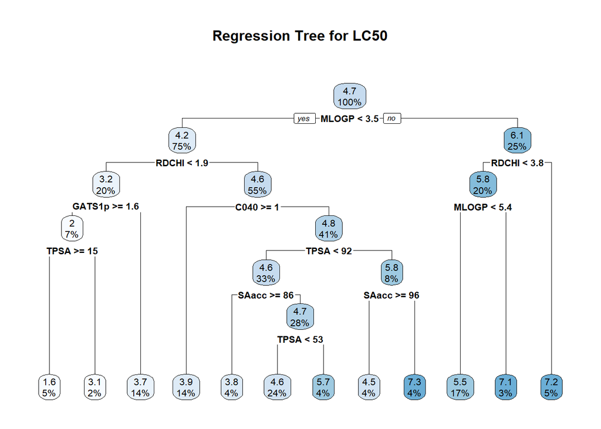

```r
# Fit the regression tree
reg_tree_mdl <- rpart(LC50 ~ TPSA + SAacc + H050 + MLOGP + RDCHI + GATS1p + nN + C040,
                    data = train_data,
                    method = "anova")

rpart.plot(reg_tree_mdl, main = "Regression Tree for LC50")
```

```r
printcp(reg_tree_mdl)
```

```
##
## Regression tree:
## rpart(formula = LC50 ~ TPSA + SAacc + H050 + MLOGP + RDCHI +
##     GATS1p + nN + C040, data = train_data, method = "anova")
##
## Variables actually used in tree construction:
## [1] C040   GATS1p MLOGP  RDCHI  SAacc  TPSA
##
## Root node error: 1061.5/366 = 2.9003
##
## n= 366
##
##         CP nsplit rel error  xerror     xstd
## 1 0.220259      0   1.00000 1.00542 0.083298
## 2 0.101418      1   0.77974 0.85128 0.073798
## 3 0.046986      2   0.67832 0.77504 0.073845
## 4 0.038398      3   0.63134 0.72634 0.074943
## 5 0.028466      6   0.51615 0.72268 0.076644
## 6 0.022545      7   0.48768 0.69955 0.072897
## 7 0.013270      8   0.46513 0.72152 0.079437
## 8 0.010957     10   0.43859 0.69873 0.072516
## 9 0.010000     11   0.42764 0.68227 0.071188
```

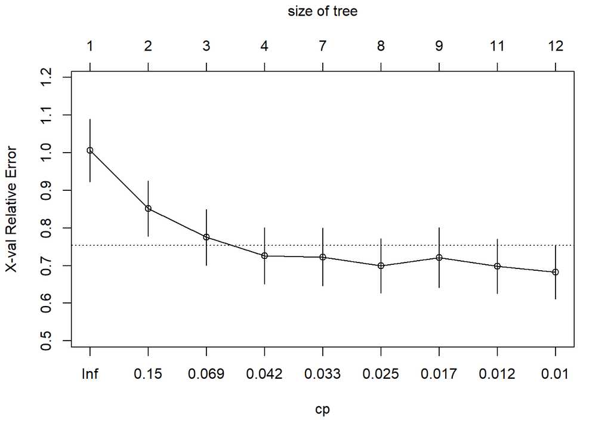

```r
plotcp(reg_tree_mdl)
```

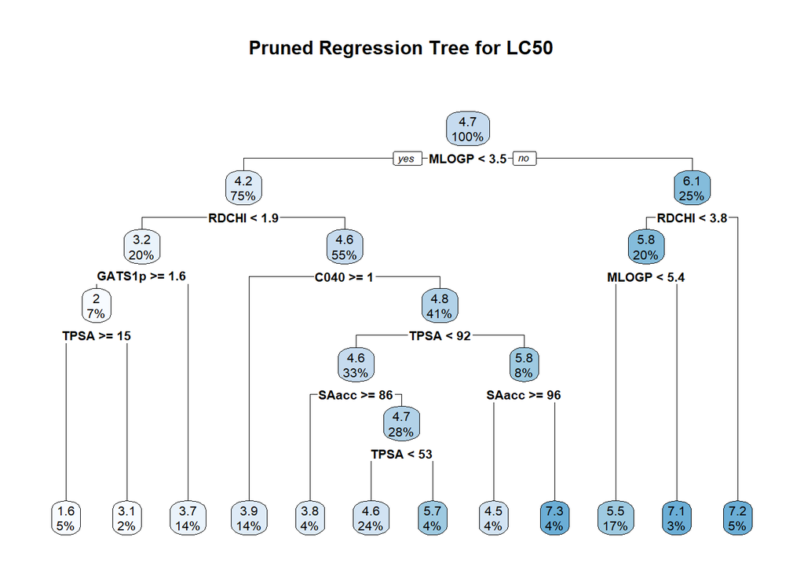

```r
# Pruning
optimal_cp <- reg_tree_mdl$cptable[which.min(reg_tree_mdl$cptable[, "xerror"]), "CP"]
reg_tree_mdl_pruned <- prune(reg_tree_mdl, cp = optimal_cp)

# pruned tree
rpart.plot(reg_tree_mdl_pruned, main = "Pruned Regression Tree for LC50")
```

```r
# test data
test_pred_reg_tree <- predict(reg_tree_mdl_pruned, newdata = test_data)

test_error_mse_reg_tree <- mean((test_pred_reg_tree - test_data$LC50)^2)
```

```r
cat("Mean Squared Error (MSE):", test_error_mse_reg_tree, "\n")
```

```
## Mean Squared Error (MSE): 1.748948
```

## 1-(g) Model comparison.

```r
results_table <- data.frame(
  Model = c(
    "1-(a)-i - Linear effect",
    "1-(a)-ii - Dummy encoded",
    "1-(b) - Boostrap - Linear effect",
    "1-(b) - Boostrap - Dummy encoded",
    "1-(c) - Variable selection",
    "1-(e) - GAM - Low Complexity",
    "1-(e) - GAM - High Complexity",
    "1-(f) - Regression Tree"
  ),
  Test_Error = c(
    test_error_linear,
    test_error_encode,
    bootstrap_avg_test_error_linear,
    bootstrap_avg_test_error_encode,
    variable_selected_mdl_test_error,
    gam_mdl_test_error_low,
    gam_mdl_test_error_high,
    test_error_mse_reg_tree
  )
)

# Create the gt table
results_table %>%
  gt() %>%
  tab_header(
    title = "Model Comparison - Test Errors"
  ) %>%
  cols_label(
    Model = "Model Type",
    Test_Error = "Test Error (MSE)"
  ) %>%
  fmt(
    columns = vars(Test_Error),
    fns = function(x) round(x, 4)
  )
```

Model Comparison - Test Errors

| Model Type | Test Error (MSE) |
| --- | --- |
| 1-(a)-i - Linear effect | 1.4107 |
| 1-(a)-ii - Dummy encoded | 1.4723 |
| 1-(b) - Boostrap - Linear effect | 1.4855 |
| 1-(b) - Boostrap - Dummy encoded | 1.539 |
| 1-(c) - Variable selection | 1.3285 |
| 1-(e) - GAM - Low Complexity | 1.4094 |
| 1-(e) - GAM - High Complexity | 1.4371 |
| 1-(f) - Regression Tree | 1.7489 |

- Variable selection shows the lowest test error. Avoided overfitting.
- Highest test error for Regression tree. Possible sing of overfitting.
- Model training with Linear effect shows low test error in general. Dummy encoding has lost necessary information for model training.
- For GAM model, low complexity shows lower test error. Avoided overfitting. However, high complexity indicates there might have been overfitting due to its high complexity.

# Problem 2. Classification

## 2-(a) k-NN

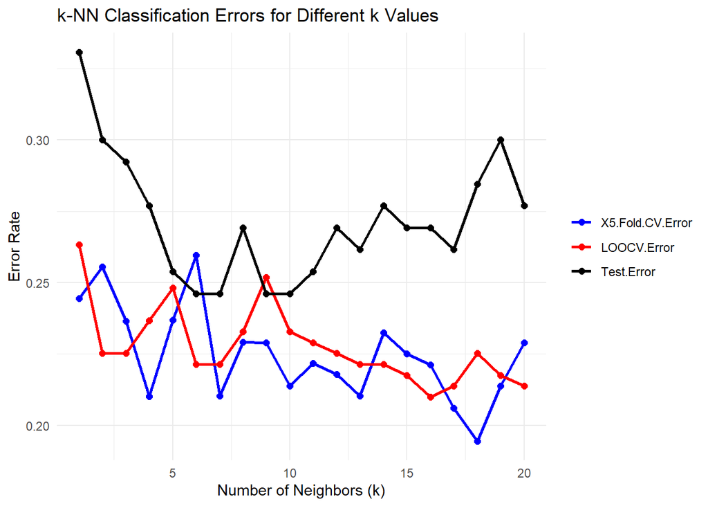

```r
# scaling
train_scaled <- train_data %>%
  mutate(across(where(is.numeric), scale))
test_scaled <- test_data %>%
  mutate(across(where(is.numeric), scale))

# Define range of k values to test
k_values <- 1:20

ctrl_cv_5_fold <- trainControl(method = "cv", number = 5)
ctrl_loocv <- trainControl(method = "LOOCV")

cv_error_5_fold <- function(k) {
  knn_model <- train(diabetes ~ .,
                     data = train_scaled,
                     method = "knn",
                     tuneGrid = data.frame(k = k),
                     trControl = ctrl_cv_5_fold)
  1 - max(knn_model$results$Accuracy)
}

cv_error_loocv <- function(k) {
  knn_model <- train(diabetes ~ ., data = train_scaled,
                     method = "knn",
                     tuneGrid = data.frame(k = k),
                     trControl = ctrl_loocv)
  1 - max(knn_model$results$Accuracy)
}

test_error <- function(k) {
  test_pred <- knn(train_scaled[,-9], test_scaled[,-9], train_scaled$diabetes, k = k)
  mean(test_pred != test_scaled$diabetes)
}

cv_errors_5fold <- purrr::map_dbl(k_values, cv_error_5_fold)
cv_errors_loocv <- purrr::map_dbl(k_values, cv_error_loocv)
test_errors <- purrr::map_dbl(k_values, test_error)

error_df <- data.frame(k = k_values,
                       `5-Fold CV Error` = cv_errors_5fold,
                       `LOOCV Error` = cv_errors_loocv,
                       `Test Error` = test_errors)

error_df_long <- reshape2::melt(error_df,
                                id.vars = "k",
                                variable.name = "Error_Type",
                                value.name = "Error")

ggplot(error_df_long, aes(x = k, y = Error, color = Error_Type)) +
  geom_line(size = 1) +
  geom_point(size = 2) +
  labs(title = "k-NN Classification Errors for Different k Values",
       x = "Number of Neighbors (k)",
       y = "Error Rate") +
  scale_color_manual(values = c("blue", "red", "black")) +
  theme_minimal() +
  theme(legend.title = element_blank())
```

```r
knn_test_error <- error_df_long %>%
  filter(grepl("Test", Error_Type)) %>%
  summarise(minimum_error = min(Error, na.rm = TRUE))

cat("Test error - KNN: ", knn_test_error$minimum_error)
```

```
## Test error - KNN:  0.2461538
```

- Test error is lowest when k = 6, 7, 9, 10. Optimal k should be one of these numbers.
- LOOCV error and CV error decrease as the number of neighbors increase.
- However, test error increases as number of k increases.
- After k = 12, the model shows the indication of underfitting.

## 2-(b) Generalized additive model

```r
# Variable selection - backward selection, AIC
gam_full <- gam(diabetes ~ s(pregnant) + s(glucose) + s(pressure) + s(triceps) +
                      s(insulin) + s(mass) + s(pedigree) + s(age),
                    family = binomial, data = train_data, select = TRUE)

summary(gam_full)
```

```
##
## Family: binomial
## Link function: logit
##
## Formula:
## diabetes ~ s(pregnant) + s(glucose) + s(pressure) + s(triceps) +
##     s(insulin) + s(mass) + s(pedigree) + s(age)
##
## Parametric coefficients:
##             Estimate Std. Error z value Pr(>|z|)
## (Intercept)  -1.1466     0.1954  -5.868 4.42e-09 ***
## ---
## Signif. codes:  0 '***' 0.001 '**' 0.01 '*' 0.05 '.' 0.1 ' ' 1
##
## Approximate significance of smooth terms:
##                   edf Ref.df Chi.sq  p-value
## s(pregnant) 1.622e+00      9  3.050  0.12527
## s(glucose)  1.000e+00      9 21.266 3.13e-06 ***
## s(pressure) 9.149e-06      9  0.000  0.82074
## s(triceps)  7.396e-06      9  0.000  0.69125
## s(insulin)  4.348e+00      9  7.825  0.09087 .
## s(mass)     2.013e+00      9  7.681  0.01110 *
## s(pedigree) 1.083e+00      9  3.965  0.02436 *
## s(age)      1.832e+00      9  9.879  0.00194 **
## ---
## Signif. codes:  0 '***' 0.001 '**' 0.01 '*' 0.05 '.' 0.1 ' ' 1
##
## R-sq.(adj) =  0.426   Deviance explained = 38.6%
## UBRE = -0.1213  Scale est. = 1         n = 262
```

```r
gam_full_pred <- predict(gam_full, newdata = test_data, type = "response")
test_data$predicted <- ifelse(gam_full_pred > 0.5, 'pos', 'neg')
test_error <- mean(test_data$predicted != test_data$diabetes)
cat("Test error - Full GAM: ", test_error)
```

```
## Test error - Full GAM:  0.1923077
```

```r
gam_selected <- gam(diabetes ~ s(glucose) + s(age) + s(mass) + s(pedigree),
                    family = binomial, data = train_data)

gam_selected_pred <- predict(gam_selected, newdata = test_data, type = "response")
test_data$predicted <- ifelse(gam_selected_pred > 0.5, 'pos', 'neg')

gam_selected_test_error <- mean(test_data$predicted != test_data$diabetes)
cat("Test error - selected GAM: ", gam_selected_test_error)
```

```
## Test error - selected GAM:  0.2076923
```

- Test error of the selected GAM model has increased.
- Selected GAM model uses 4 features while full GAM model uses 8 features.

## 2-(c) Decision Tree

### 2-(c)-i Classification tree

```r
# Classification Tree
tree_model <- rpart(diabetes ~ ., data = train_data, method = "class")
tree_pred_train <- predict(tree_model, train_data, type = "class")
tree_pred_test <- predict(tree_model, test_data, type = "class")

tree_train_error <- mean(tree_pred_train != train_data$diabetes)
tree_test_error <- mean(tree_pred_test != test_data$diabetes)
```

### 2-(c)-ii Ensemble of bagged tree

```r
# Bagged Trees
bagged_model <- bagging(diabetes ~ ., data = train_data, coob = TRUE)
bagged_pred_train <- predict(bagged_model, train_data)
bagged_pred_test <- predict(bagged_model, test_data)

bagged_train_error <- mean(bagged_pred_train != train_data$diabetes)
bagged_test_error <- mean(bagged_pred_test != test_data$diabetes)
```

### 2-(c)-iii Random forest

```r
# Random Forest
rf_model <- randomForest(diabetes ~ ., data = train_data)
rf_pred_train <- predict(rf_model, train_data)
rf_pred_test <- predict(rf_model, test_data)

rf_train_error <- mean(rf_pred_train != train_data$diabetes)
rf_test_error <- mean(rf_pred_test != test_data$diabetes)
```

### 2-(c)-result

```r
results_df <- data.frame(
  Model = c("Classification Tree", "Bagged Trees", "Random Forest"),
  Training_Error = c(tree_train_error, bagged_train_error, rf_train_error),
  Test_Error = c(tree_test_error, bagged_test_error, rf_test_error)
)

results_table <- results_df %>%
  gt() %>%
  fmt_number(columns = c("Training_Error", "Test_Error"), decimals = 4) %>%
  tab_header(
    title = "Training and Test Errors",
  ) %>%
  cols_label(
    Model = "Model",
    Training_Error = "Training Error",
    Test_Error = "Test Error"
  ) %>%
  tab_style(
    style = cell_fill(color = "lightblue"),
    locations = cells_column_labels()
  ) %>%
  tab_style(
    style = cell_text(weight = "bold"),
    locations = cells_column_labels()
  )

results_table
```

Training and Test Errors

| Model | Training Error | Test Error |
| --- | --- | --- |
| Classification Tree | 0.1145 | 0.2462 |
| Bagged Trees | 0.0000 | 0.2462 |
| Random Forest | 0.0000 | 0.2231 |

#### 2-(c)-result-Classification Tree:

- Highest test error.
- Simple and can capture non-linear relationships in the data.
- Possibility of overfitting the training data, a higher test error.

#### 2-(c)-result-Random Forest:

- Introduces randomness in the feature selection process.
- Decorrelates the trees and reduces overfitting.

## 2-(d) Neural Network

```r
# scaling
train_scaled <- train_data %>%
  mutate(across(where(is.numeric), scale))
test_scaled <- test_data %>%
  mutate(across(where(is.numeric), scale))

ctrl <- trainControl(method = "cv", number = 5)

# grid search - size of NN, regularization
grid <- expand.grid(size = seq(1, 20, by = 2), decay = c(0, 0.1, 0.5, 1))

set.seed(123)
nn_model <- train(diabetes ~ .,
                  data = train_scaled,
                  method = "nnet",
                  tuneGrid = grid,
                  trControl = ctrl,
                  linout = FALSE,
                  trace = FALSE,
                  maxit = 200)

# best nn model
print(nn_model$bestTune)
```

```
##    size decay
## 15    7   0.5
```

```r
nn_train_pred <- predict(nn_model, newdata = train_scaled)
nn_test_pred <- predict(nn_model, newdata = test_scaled)

nn_train_error <- mean(nn_train_pred != train_data$diabetes)
nn_test_error <- mean(nn_test_pred != test_data$diabetes)

cat("Training Error: ", nn_train_error, "\n")
```

```
## Training Error:  0.1984733
```

```r
cat("Test Error: ", nn_test_error, "\n")
```

```
## Test Error:  0.2230769
```

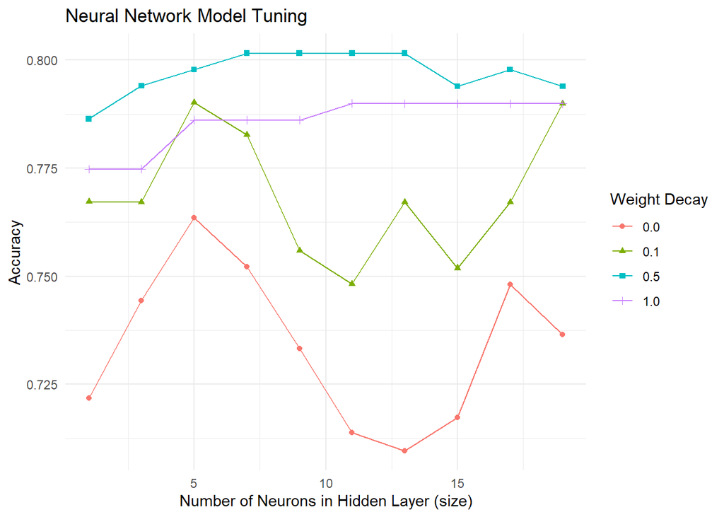

```r
ggplot(nn_model) +
  labs(title = "Neural Network Model Tuning",
       x = "Number of Neurons in Hidden Layer (size)",
       y = "Accuracy") +
  theme_minimal()
```

- grid search is implemented: size from 1-20, decay factor(0, 0.1, 0.5, 1)
- Best NN model: size = 7, decay = 0.5

## 2-(e) Model comparison

```r
results_table <- data.frame(
  Model = c(
    "KNN",
    "GAM",
    "Classification Tree",
    "Bagged Tree",
    "Random Forest",
    "Neural Network"
  ),
  Test_Error = c(
    knn_test_error$minimum_error,
    gam_selected_test_error,
    tree_test_error,
    bagged_test_error,
    rf_test_error,
    nn_test_error
  )
)

# Create the gt table
results_table %>%
  gt() %>%
  tab_header(
    title = "Model Comparison - Test Errors"
  ) %>%
  cols_label(
    Model = "Model Type",
    Test_Error = "Test Error"
  ) %>%
  fmt(
    columns = vars(Test_Error),  # Use vars() to specify the columns
    fns = function(x) round(x, 4)  # Round to 4 decimal places
  )
```

Model Comparison - Test Errors

| Model Type | Test Error |
| --- | --- |
| KNN | 0.2462 |
| GAM | 0.2077 |
| Classification Tree | 0.2462 |
| Bagged Tree | 0.2462 |
| Random Forest | 0.2231 |
| Neural Network | 0.2231 |

- Final model selection: **GAM**
- GAM has the lowest test error.
- Feature selection has been conducted in GAM.
- Able to assess the features’ impact on the response variable.
- GAM is highly interpretable.
- Random forest has the second lowest test error.
- Neural Network does not seem to be efficient considering its computational burdensome.